# Irish Housing Market Analysis

### 3. **The Uneven Recovery: Regional Growth Since 2010**

Which regions experienced the most aggressive price inflation during the post-crash recovery?

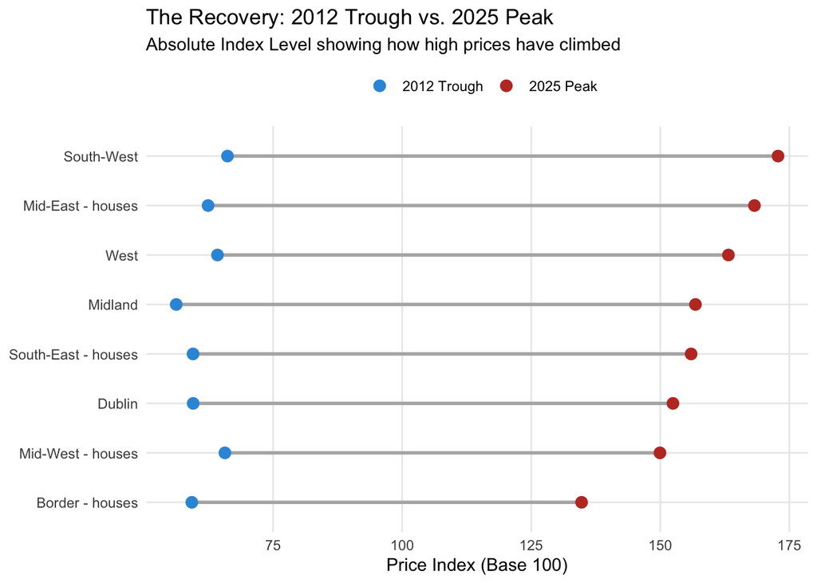

Figure 6

```r
db_df <- df %>%
  filter(STATISTIC == "HPM06C01",
         `Type of Residential Property` %in% c(
           "Dublin - houses",
           "Border excluding Louth - houses",
           "Midland - houses",
           "West - houses",
           "Mid-East including Louth - houses",
           "Mid-West including South Tipperary - houses",
           "South-East excluding South Tipperary - houses",
           "South-West - houses"
         )) %>%
  mutate(Year = substr(Month, 1, 4),
         VALUE = as.numeric(VALUE),
         Region = str_remove(`Type of Residential Property`, " - houses| excluding Louth| including Louth| including South Tipperary| excluding South Tipperary")) %>%
  filter(Year %in% c("2012", "2025")) %>%
  group_by(Region, Year) %>%
  summarise(Index = mean(VALUE, na.rm = TRUE), .groups = "drop") %>%
  pivot_wider(names_from = Year, values_from = Index) %>%
  drop_na() %>%
  # Sorts the y-axis by the absolute highest peak in 2025
  mutate(Region = reorder(Region, `2025`))

# 2. Build the Dumbbell Plot
ggplot(db_df, aes(y = Region)) +
  geom_segment(aes(x = `2012`, xend = `2025`, y = Region, yend = Region), color = "gray70", linewidth = 1) +
  geom_point(aes(x = `2012`, color = "2012 Trough"), size = 3) +
  geom_point(aes(x = `2025`, color = "2025 Peak"), size = 3) +
  scale_color_manual(values = c("2012 Trough" = "#3498db", "2025 Peak" = "#c0392b")) +
  theme_minimal() +
  theme(legend.position = "top", panel.grid.minor = element_blank()) +
  labs(title = "The Recovery: 2012 Trough vs. 2025 Peak",
       subtitle = "Absolute Index Level showing how high prices have climbed",
       x = "Price Index (Base 100)", y = NULL, color = "")
```

### 4. The Apartment/House Divide

Did buyers’ preferences for property types shift after the crash?

Apartments and houses did not recover equally. This ribbon chart encodes the gap between the two as a filled area, red shading shows when apartments trade below houses. The widening post-crash gap reveals a structural shift in buyer preference toward houses.

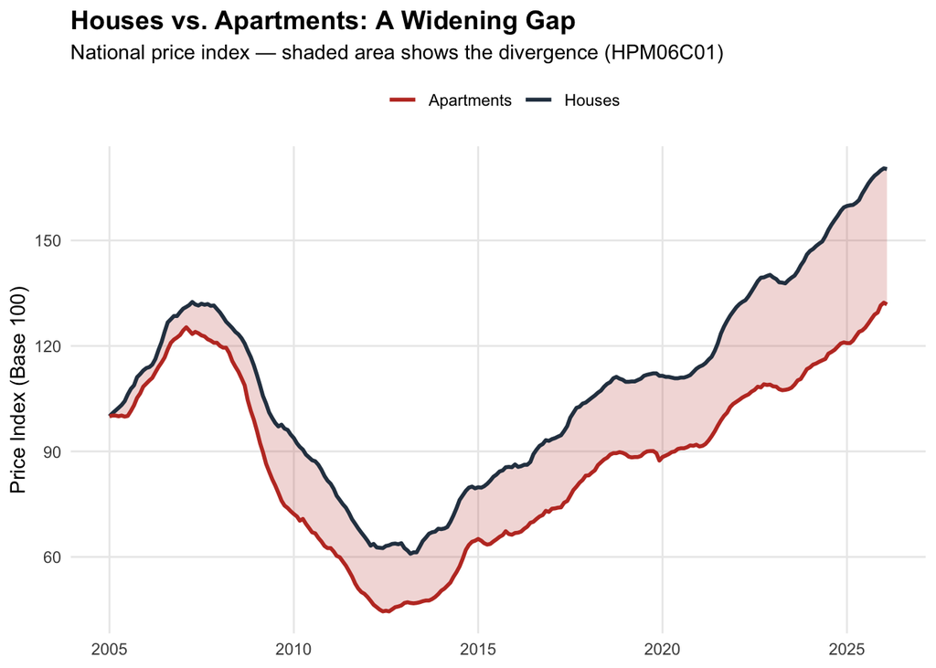

Figure 7

```r
ggplot(ribbon_df, aes(x = Date)) +
  geom_ribbon(aes(ymin = pmin(Houses, Apartments),
                  ymax = pmax(Houses, Apartments)),
              fill = "#c0392b", alpha = 0.2) +
  geom_line(aes(y = Houses,     color = "Houses"),     linewidth = 1) +
  geom_line(aes(y = Apartments, color = "Apartments"), linewidth = 1) +
  scale_color_manual(values = c("Houses"     = "#2c3e50",
                                "Apartments" = "#c0392b")) +
  theme_minimal() +
  theme(panel.grid.minor = element_blank(),
        legend.position  = "top",
        plot.title       = element_text(face = "bold", size = 14)) +
  labs(title    = "Houses vs. Apartments: A Widening Gap",
       subtitle = "National price index — shaded area shows the divergence (HPM06C01)",
       x        = NULL,
       y        = "Price Index (Base 100)",
       color    = "")
```